# SDS_315_HW_2

## Part C

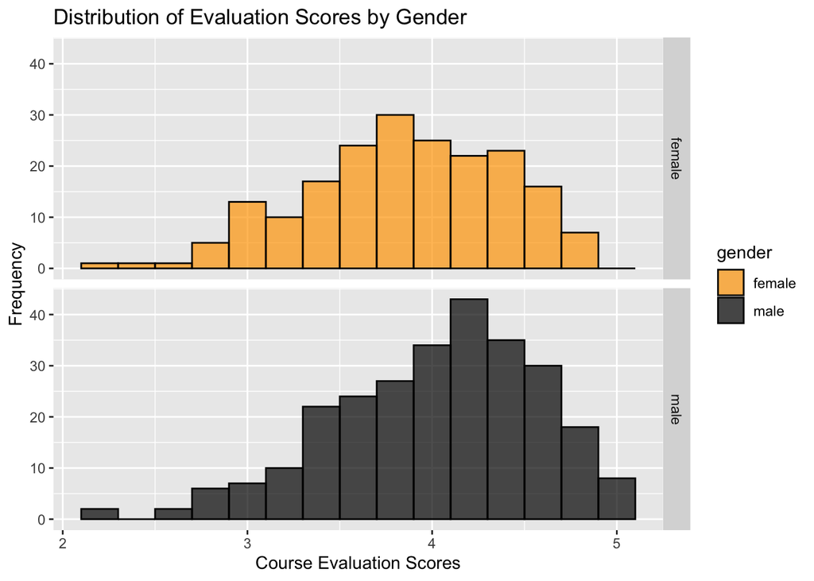

When comparing genders while they have similar evaluation distributions, there is a slightly greater group of scores in the 4.- to 4.5 range male scores. However males and females have similar median scores with a .1 difference seperating the two. However in males the graph shows a higher concentration at 4. opposed to a more equitable distribution in female evaluation scores.

## Part D

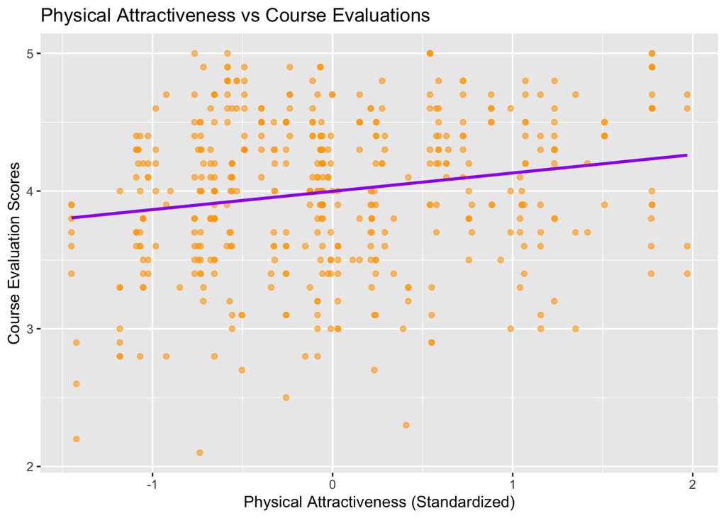

The analysis of the graph shows a weak positive correlation of .192 between attractiveness and evaluations. Something interesting was that the instructors rated 1 standard deviation above average attractiveness tend to receive evaluations 0.3 points higher than those 1 standard deviation below average.